# Sprawozdanie 1

## Zadanie 1

**Wybraną spółką do analizy, jest CD Projekt Red.**

Dane wyglądają następująco:

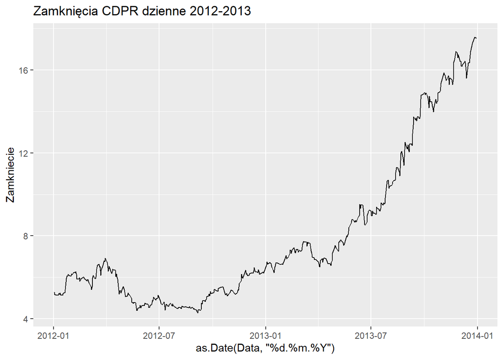

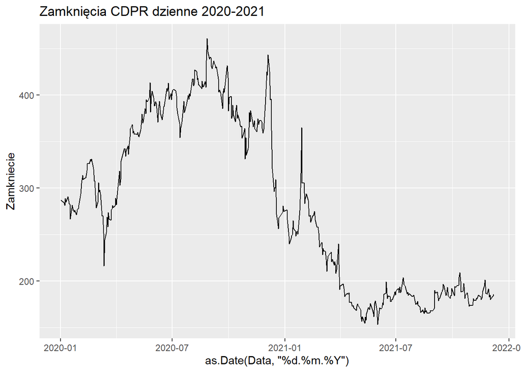

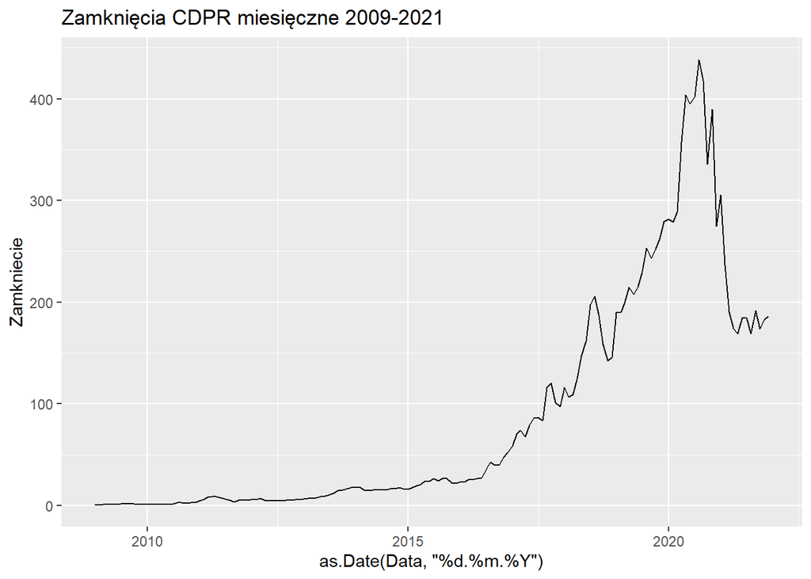

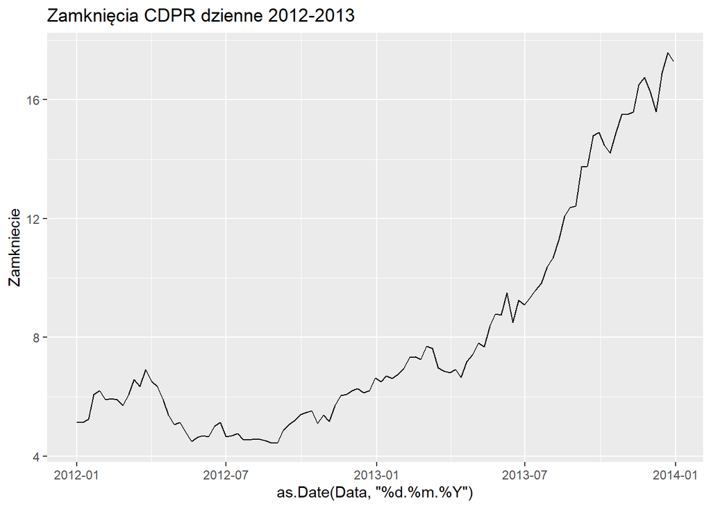

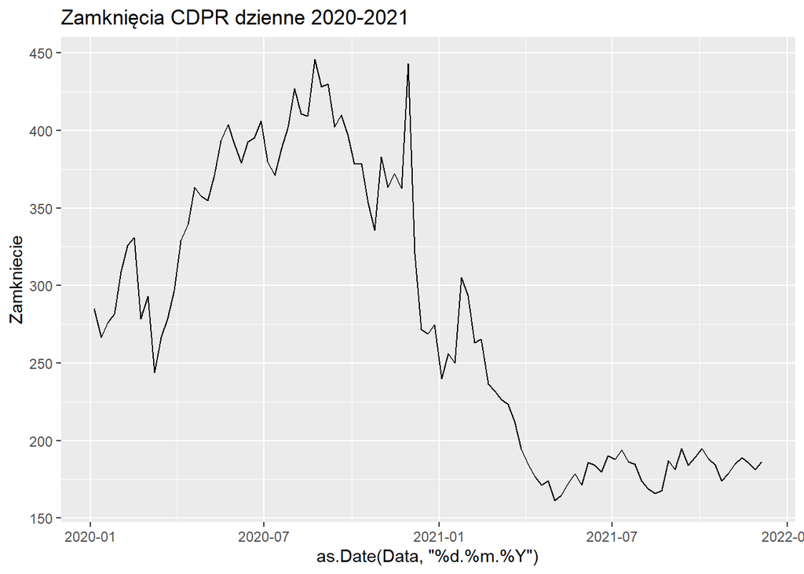

Dla pierwszych dwóch zbiorów danych obliczono dzienne proste i logarytmiczne stopy zwrotu, a dla trzeciego - miesięczne.

Zrobiono to przy użyciu pakietu

```r
library(dplyr)
```

- Najpierw zmieniając wczytaną z pliku zmienną Date na format daty,
- Następnie sortując dane według zmiennej Date
- I tworząc prostą stopę zwrotu wg wzoru
  $$U_p(t) = 100*\frac{X_t-X_{t-1}}{X_{t-1}}$$
- Oraz stopę logarytmiczną wg wzoru
  $$U_l(t) = 100*ln(\frac{X_t}{X_{t-1})}$$

```r
daned2012$Data<-as.Date(daned2012$Data,"%d.%m.%Y") ##Zmiana formatu
daned2012<-daned2012 %>%
  arrange(Data) %>% ##Sort
    mutate(prosta = (Zamkniecie-lag(Zamkniecie))/lag(Zamkniecie)*100) %>%#prosta
      mutate(logarytm = log(Zamkniecie/lag(Zamkniecie))*100) #logarytmiczna
head(daned2012)
```

```
##         Data Zamkniecie Otwarcie  Max  Min     Wol Zmiana     prosta   logarytm
## 1 2012-01-02       5.28     5.24 5.38 5.24 497,37K  0,19%         NA         NA
## 2 2012-01-03       5.16     5.26 5.27 5.15 330,75K -2,27% -2.2727273 -2.2989518
## 3 2012-01-04       5.15     5.16 5.21 5.07 152,83K -0,19% -0.1937984 -0.1939865
## 4 2012-01-05       5.13     5.09 5.15 5.04 158,10K -0,39% -0.3883495 -0.3891055
## 5 2012-01-09       5.13     5.11 5.15 5.03 171,41K  0,00%  0.0000000  0.0000000
## 6 2012-01-10       5.23     5.15 5.30 5.10 376,77K  1,95%  1.9493177  1.9305619
```

Cały proces powtórzono dla wszystkich zbiorów danych.

Na wykresach poniżej, przy użyciu pakietów ggplot2, magrittr oraz multipanelfigure przedstawiono odpowiednio dzienne i miesięczne stopy zwrotu w czasie:

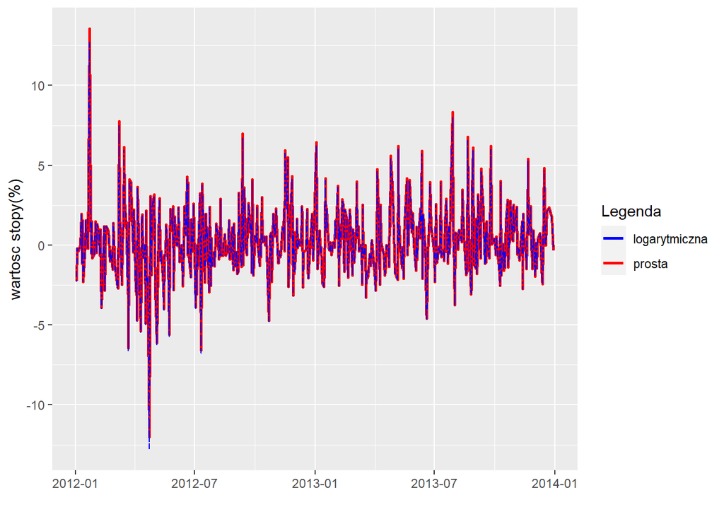

```r
library(ggplot2)
library(magrittr)
library(multipanelfigure)
```

Na podstawie powyższego wykresu zmian dziennych mozna zauważyć, że różnice pomiędzy stopą logarytmiczną a prostą są bardzo małe.

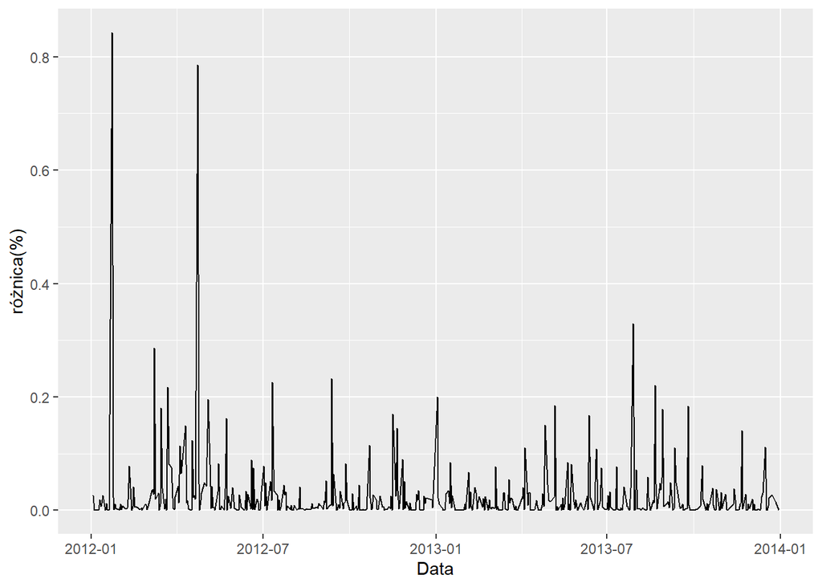

Robiąc wykres różnic między wartościami stopy prostej a logarytmicznej, można stwierdzić, że rzeczywiście, różnice między stopami nie przekraczają 1%.

Na wykresach poniżej można zobaczyć zestawienie dla wszystkich pozostałych zbiorów danych i wszystkich okresów czasowych:

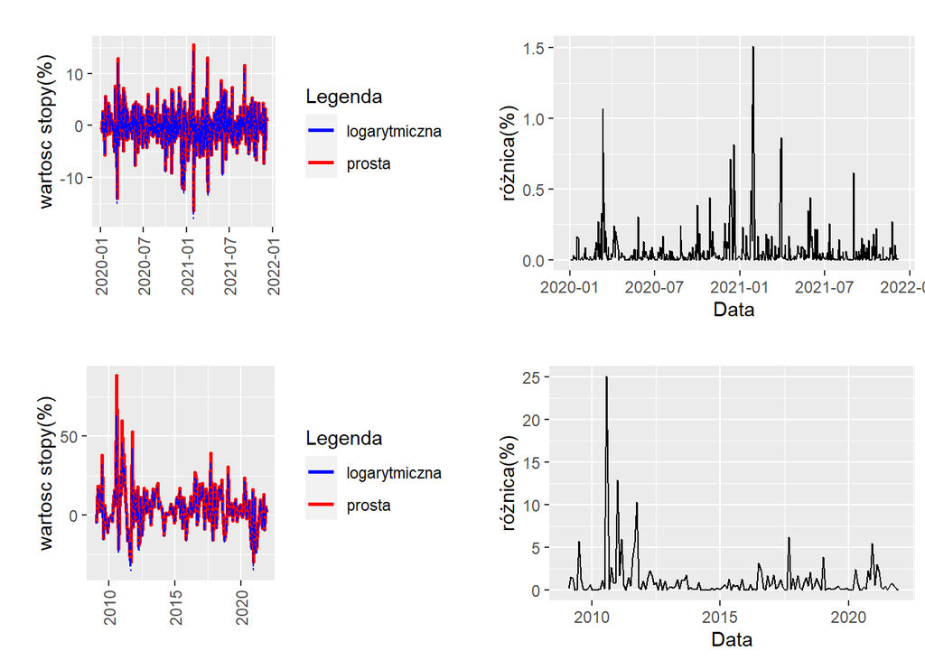

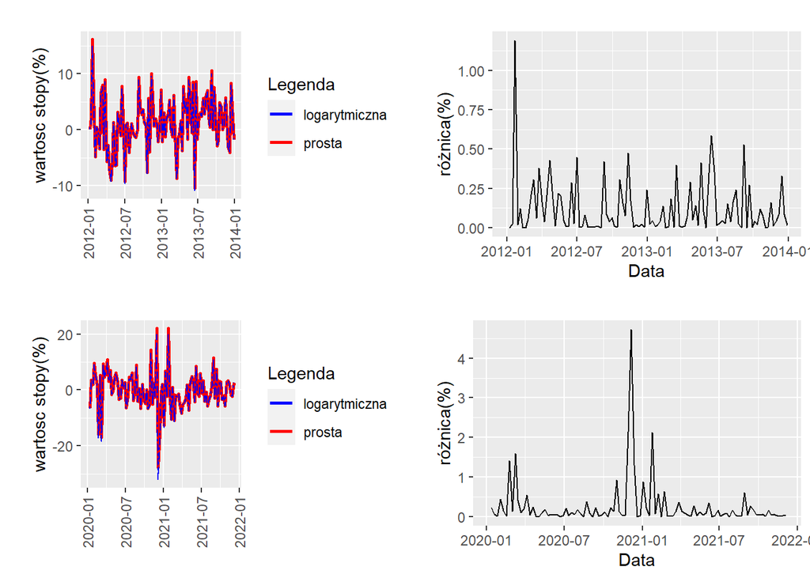

Warto też dodać, że różnica została obliczona w postaci
$$U_p-U_l$$
co nakazuje twierdzić, że wartości prostej stopy zwrotu są wyższe niż wartości stopy logarytmicznej.

## Zadanie 2

Dla wartości stóp prostych oraz logarytmicznych sprawdzono, czy należą one do rozkładu normalnego przy pomocy trzech testów:

- Shapiro-Wilka
- Andersona-Darlinga
- Jarque-Bery

```r
library(tseries)
library(nortest)
```

Nie dotyczy to jednak wszystkich stóp dla danych tygodniowych, bo te z przedziału 2020-2021, nie mają rozkładu normalnego na poziomie istotności 5%.

Wspierając się wynikami dla innych interwałów czasowych, można sądzić, że przez przypadek stopy logarytmiczne dla danych tygodniowych z lat 2012-2013 posiadają rozkład normalny. Należałoby to jednak poddać dodatkowemu badaniu uwzględniając jedynie stopy z danych tyogdniowych.

## Zadanie 3

```
##       Hipotetyczne ~N(m,sd) Realne
## <1SD                   1800   2104
## 1-2SD                   763    432
## 2-3SD                   121    111
## 3-4SD                     3     21
## 4-5SD                     0     11
## >5SD                      0      8
```

Na podstawie powyższej tabeli można stwierdzić, że logarytmiczne stopy zwrotu dla danych realnych znacznie bardziej odstają od średniej niż dane pochodzące z rozkładu normalnego.

Można więc sądzić, że realny rozkład stóp logarytmicznych posiada wahannia, których amplituda może przekraczać nawet 5 odchyleń standardowych.

## Zadanie 4

Aby sprawdzić zgodność rozkładu dziennych stóp logarytmicznych z okresu lat 2009-2021 z teoretyzcnymi rozkładami posłużono się poniżsyzm wykresem:

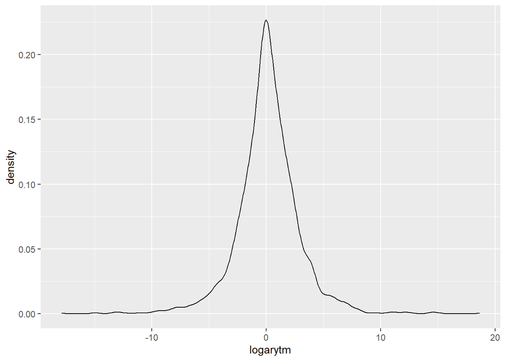

Na podstawie oceny wizualnej, mozna odrzucić zgodność z rozkładami takimi jak:

- rozkład jednostajny,
- rozkład F,
- rozkład chi-kwadrat,
- rozkład wykładniczy,
- rozkład gamma,
- rozkład log-normalny.

Także na podstawie oceny wizualnej, można wybrac kandydatów na sprawdzenie zgodności i są nimi:

- rozkład Laplace’a,
- rozkład t-Studenta.

Wynkonano kilkanaście prób nałożenia na siebie wykresów gęstości w zależności od parametrów powyższych rozkładów. Tak prezentują się wyksresy najbardziej nakładające się na tle rozkładu empirycznego:

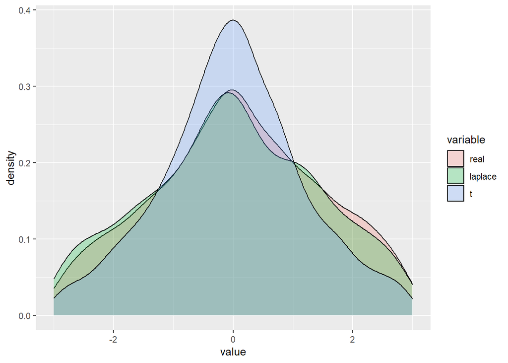

Po dokładniejszej analizie, można zobaczyć, że rozkład laplace’a ze średnią 0 i czynnikiem skali 2 z rozkładem empirycznym praktycznie się na siebie nakładają.

Wykonano więc, test Kołomogorowa-Smirnowa zgodności rozkładu empirycznego z rozkładem laplace’a z powyższymi parametrami, oraz z rozkładem t-Studenta. Wyniki zamieszczono

```
##
##  Two-sample Kolmogorov-Smirnov test
##
## data:  x$real and x$laplace
## D = 0.043543, p-value = 0.01226
## alternative hypothesis: two-sided
```

```
##
##  Two-sample Kolmogorov-Smirnov test
##
## data:  x$t and x$real
## D = 0.076293, p-value = 3.226e-07
## alternative hypothesis: two-sided
```

Na podstawie wyników, na poziomie istotności 5% można stwierdzić, ze nie ma podstaw aby sądzić, że rozkład danych dziennych stóp zwrotu dla badanych danych ma rozkład laplacea z parametrami 0 i 2 czy też rozkład t-studenta z 1 stopniem swobody.